# небольшой_анализ_продлений

Отчёт посвящён продлениям и сравнению процента продлений в разных группах.

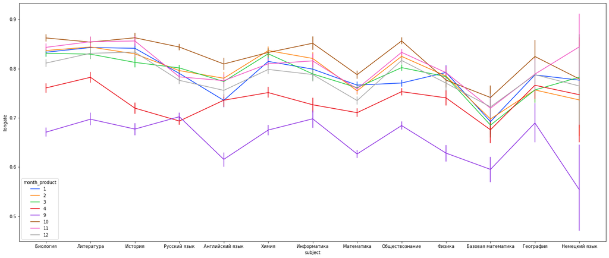

Любопытный график выше

Проверим вторую теорию

Процент учеников перешедших из апреля в май - 73.34 %

Процент учеников перешедших из апреля в предбанник не взяв мастер-группу - 9.49%

Если посмотреть на продление в разные месяцы, то получается такая картина:

Месяцы/продления

Итак, можно считать, что наше предположение подтвердилось.

В лучший месяц процент продлений был **84.14% (Октябрь)**, а второй **81.50% (Ноябрь)**.

Если считать, что из апреля в май перешло **73.34%** - в мг + **9.49%** - сразу на предбанник, то можно считать, что **82.83%** перешли из апреля в май. Это нисколько не является заниженным показателем.

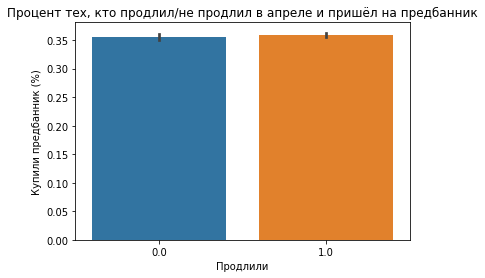

- Интересный момент, который я заметил попутно. Из ребят, которые продлили и не продлили в апреле, практически одинаковый процент пошли на предбанник.

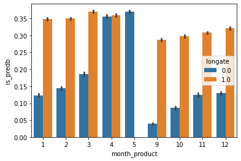

- Интересный график сверху. Начиная от сентября и заканчивая мартом у нас растёт процент тех, кто в итоге запишется на предбанник, причём как среди тех, кто продлевает месяц, так и среди тех, кто уходит.
- Однако, процент тех кто "Остается" и оказывается на предбаннике растёт медленно и скорее находится на одном уровне около 30%, в то время как среди уходящих, но пришедших на предбанник наблюдается значимый рост

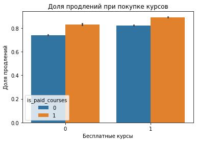

- График сверху демонстрирует, что среди тех кто использует бесплатные курсы - продлений больше, а так же среди тех кто использует бесплатные курсы совместно с платными - ещё больший процент продления.

Иначе говоря "вероятность продления" при покупке бесплатных курсов или платных курсов - одинакова.